# 210522_HeatmapsOfRelevantGenes

Erin Osborne Nishimura

5/22/2021

# Analysis: Heatmaps of key gene signature sets

The purpose of this analysis is to assess how gene signature sets are changing our datasets. Previous publications have reported the transcriptional profiles associated with different types of pathway activation.

For this analysis, we used the following publications:

- Creighton CJ. [A gene transcription signature of the Akt/mTOR pathway in clinical breast tumors](https://doi.org/10.1038/sj.onc.1210245). *Oncogene* **2007**;26:4648–55.
- Dry JR, Pavey S, Pratilas CA, Harbron C, Runswick S, Hodgson D, et al. [Transcriptional Pathway Signatures Predict MEK Addiction and Response to Selumetinib (AZD6244)](https://doi.org/10.1158/0008-5472.can-09-1577). *Cancer Res* **2010**;70:2264–73.
- Loboda A, Nebozhyn M, Klinghoffer R, Frazier J, Chastain M, Arthur W, et al. [A gene expression signature of RAS pathway dependence predicts response to PI3K and RAS pathway inhibitors and expands the population of RAS pathway activated tumors.](https://doi.org/10.1186/1755-8794-3-26) *Bmc Med Genomics* **2010**;3:26.
- Pratilas CA, Taylor BS, Ye Q, Viale A, Sander C, Solit DB, et al. [V600EBRAF is associated with disabled feedback inhibition of RAF–MEK signaling and elevated transcriptional output of the pathway.](https://doi.org/10.1073/pnas.0900780106) *Proc National Acad Sci* **2009**;106:4519–24.
- Wagle M-C, Kirouac D, Klijn C, Liu B, Mahajan S, Junttila M, et al. [A transcriptional MAPK Pathway Activity Score (MPAS) is a clinically relevant biomarker in multiple cancer types](https://doi.org/10.1038/s41698-018-0051-4). *Npj Precis Oncol* **2018**;2:7.

## Step 1: Load packages

```r
library(RColorBrewer)
library(ggplot2)
library(dplyr)
library(pheatmap)
library(reshape2)
library(pryr)
```

## Step 2: Set Today’s date:

```
## [1] "210522"
```

## Step 3: Import the data we generated -

These are R-stabilized log normalized read counts of the RNA-seq dataset we generated. Three replicate each of ARPE19 cells, T53D4 cells, AKT-activated cells, MEK-activated cells, and RAS-actived cells.

```r
# This was an output from: 210128_DESeq_analyze_EONversion
rlog_counts <- read.table(file = "../01_input/210215_RStabilized_log_counts.txt", header = TRUE)
```

Reorganize the rlog_counts file so that samples are grouped by condition.

## Step 4: Write some functions:

Write the following functions that will be used in this analysis:

**subset_counts_by_external_df**(dataframe_of_rld, vector_of_commongenes)

- dataframe_of_rld - r-stabilized log normalized counts data frame
- vector_of_commongenes - a vector list of common gene names to subset
- This function extracts the genes in the vector list from the dataframe given.

**subset_counts_by_ensembl_df**(dataframe_of_rld, vector_of_ensemblgenes)

- dataframe_of_rld - r-stabilized log normalized counts data frame
- vector_of_ensemblgenes - a vector list of ensemble gene identifiers to subset
- This function extracts the genes in the vector list (in Ensemble gene ID form) from the dataframe given.

**identify_missing_genes**(dataframe_of_rld, vector_of_commongenes)

- dataframe_of_rld - r-stabilized log normalized counts data frame
- vector_of_commongenes - a vector list of common gene names to subset
- This function determines whether there were any genes that did not successfully match up.

**return_labeled_matrix**(dataframe)

- Convert data frame to a matrix and make common gene names the rownames

```r
subset_counts_by_external_df <- function(dataframe_of_rld, vector_of_commongenes){
  subset_df <- dataframe_of_rld[dataframe_of_rld$external_gene_name %in% vector_of_commongenes,]
  return(subset_df)
}

subset_counts_by_ensembl_df <- function(dataframe_of_rld, vector_of_ensemblgenes){
  subset_df <- dataframe_of_rld[dataframe_of_rld$EnsembleGeneName %in% vector_of_ensemblgenes,]
  return(subset_df)
}

identify_missing_genes <- function(dataframe_of_rld, vector_of_commongenes){
  vector_missing <- vector_of_commongenes[(!vector_of_commongenes %in% dataframe_of_rld$external_gene_name)]
  return(vector_missing)
}

return_labeled_matrix <- function(dataframe){
  matrix <- as.matrix(dataframe[ , 3:dim(dataframe)[2]])
  rownames(matrix) <- dataframe$external_gene_name
  return(matrix)
}
```

## Step 4: Write some functions for performing statistical analyses.

Import the lists of changing genes from the DESeq2 analysis.

Write a function called *make_contingency_table* that creates contingency tables for statistical analyses:

Write a function called *vector_of_p_values* that creates a vector of p-values generated from comparisons with the DESeq2 differentially expressed genes expressing the likeliness that a given gene signature set of genes are **enriched** amongst the list of genes.

Write a function called *vector_of_depletion_p_values* that creates a vector of p=values generated from comparisons with the DESeq2 differentially expressed genes expressing the likeliness that a given gene signature set of genes are **depleted** amongst the list of genes.

Write a function called *calculate_percent_enrichment* that calculates the over-representation between a published gene signature and the gene sets from our RNA-seq analysis. Our gene sets are lists of genes that are Up compared to ARPE-19 or down compared to ARPE-19 at a 0.1 adjusted p-value threshold and a 0.25 minimum log fold change.

Percent enrichment is calculated as:
$$\text{Percent enrichment}= \displaystyle \left(\frac{\text{set and list intersection}}{\text{GME list length}}\right)100\%$$

Write a function called *calculate_fold_enrichment* that calcualets the fold enrichment between a published genes signature set and the genesets from our RNA-seq analysis.

Fold enrichment calculated as:
$$\text{Fold enrichment}= \displaystyle \frac{\text{percent enrichment in GME}}{\text{percent enrichment genomewide}}$$

## Step 5: Select genes in different branches of the RAS/AKT/MEK pathways:

These are the genes that were altered as part of the transformation process.

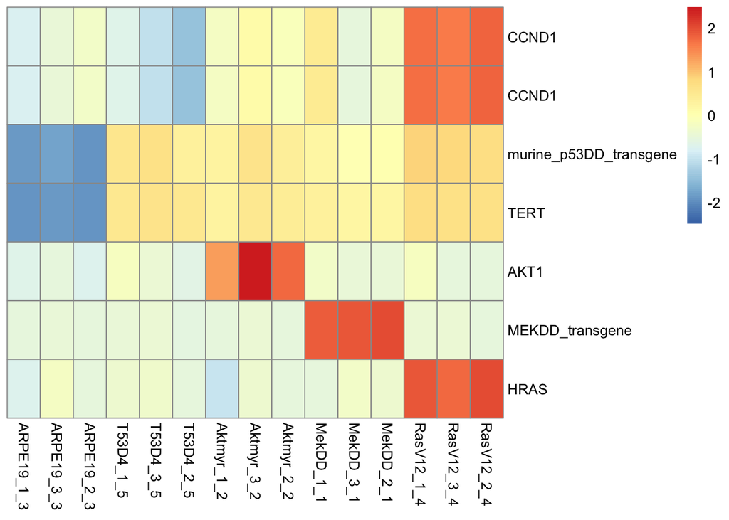

## Step 5: Compare to Dry et al., 2010 - Mek-18 gene signature (18 genes)

This a gene signature set of genes that are predicted to be up-regulated with Mek-pathway activation.

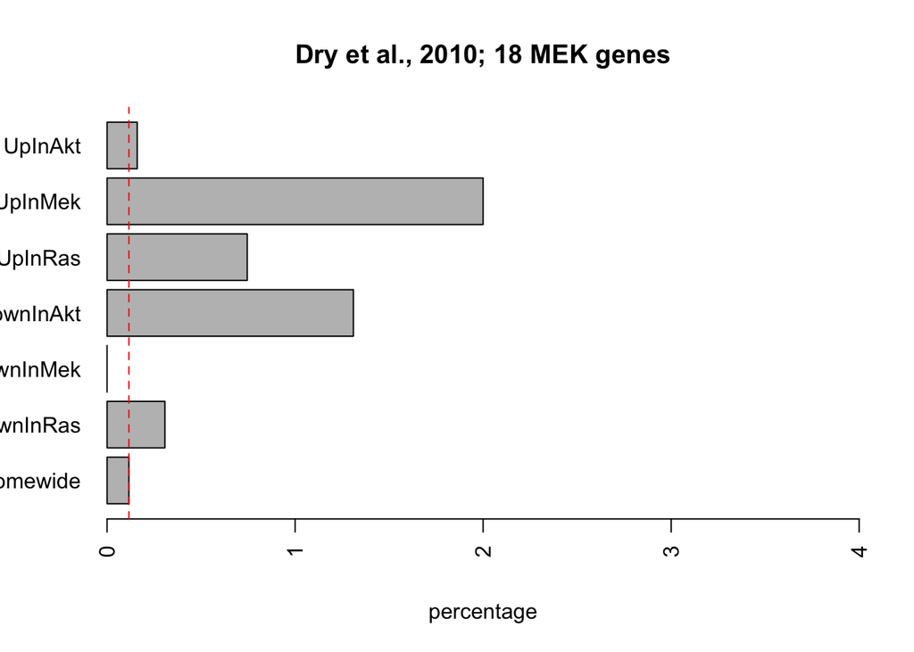

Heatmap of genes in the Mek 18 gene list:

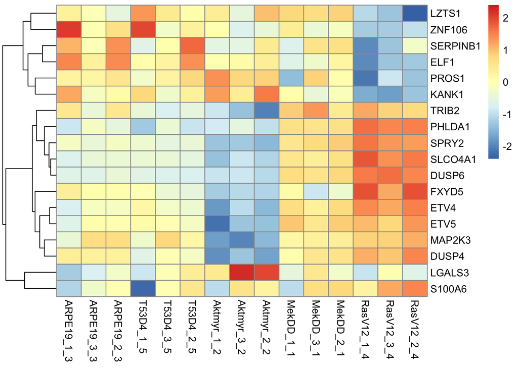

These are predicted to be up-regulated with Mek-pathway activation.

```
##   UpInAkt   UpInMek   UpInRas
## 0.4968269 9.3006000 6.6453495
```

```
## DownInAkt DownInMek DownInRas
## 8.5740611 0.0000000 0.1907815
```

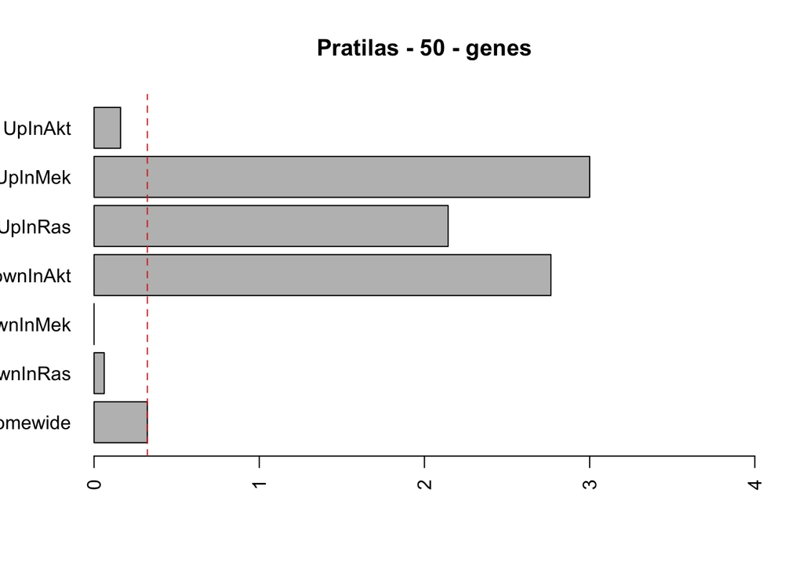

Plot the heatmap of genes in the Pratilas gene set:

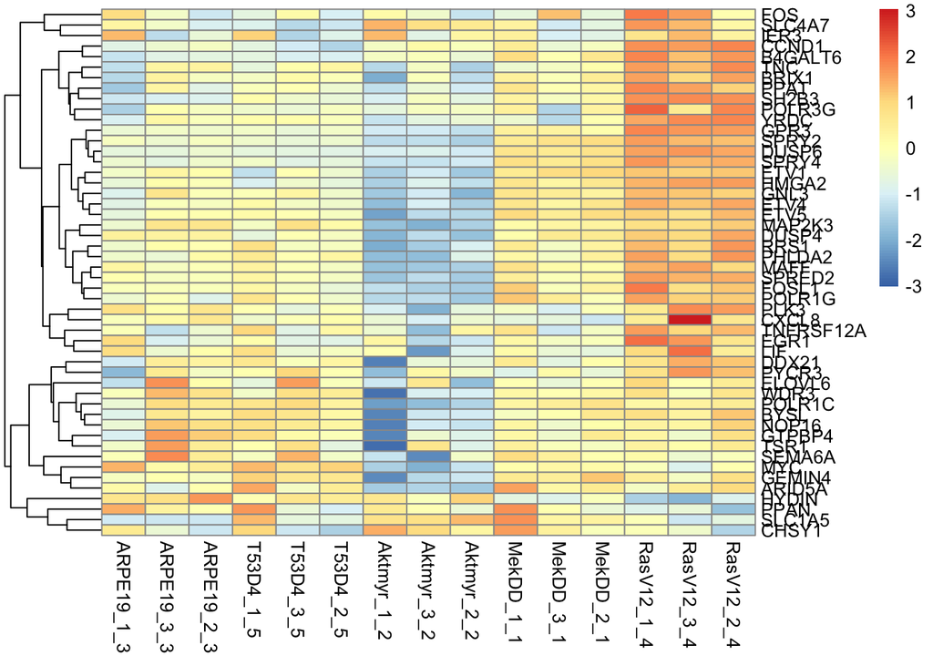

## Step 7: Wagle et al., 2018. MEK pathway (10 genes)

These are predicted to be up-regulated with Mek-pathway activation.

```
##  UpInAkt  UpInMek  UpInRas
##  0.00000 31.00200 11.55713
```

```
## DownInAkt DownInMek DownInRas
##  15.79432   0.00000   0.00000
```

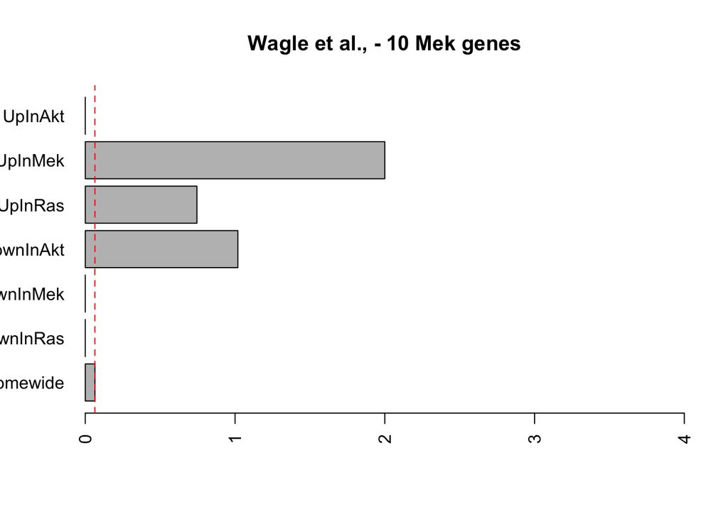

Plot the heatmap of the genes in the Wagle geneset:

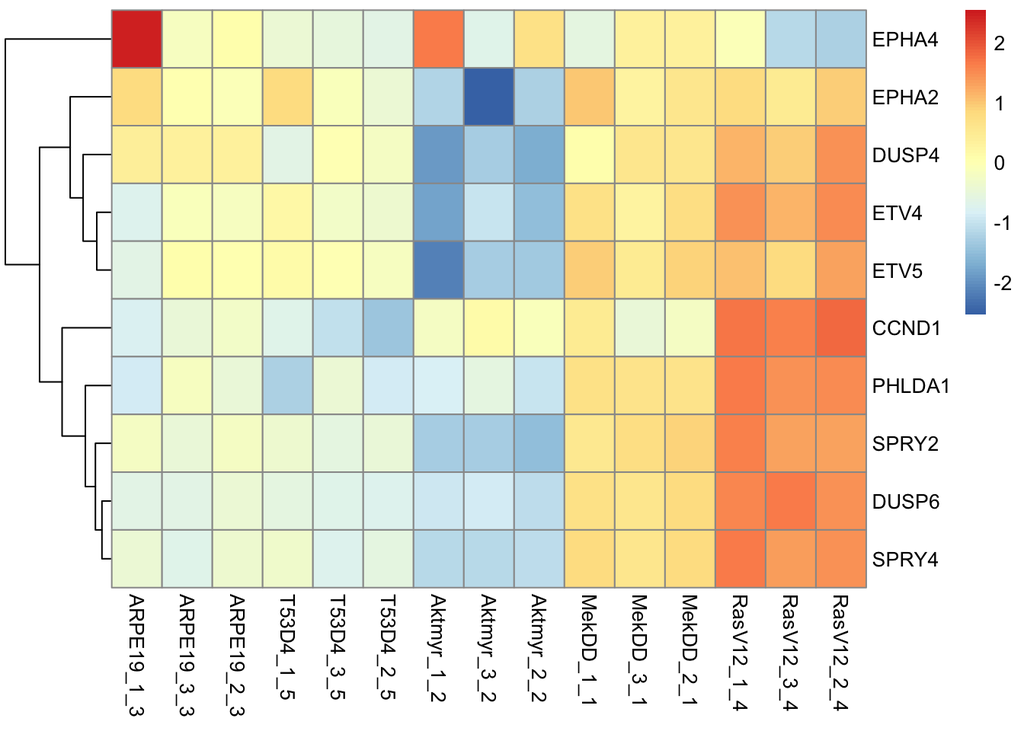

## Step 8: Creighton et al, 2007. AKT/mTOR pathway (57)

These are predicted to be up-regulated with AKT activation specifically in breast tumors

```
##   UpInAkt   UpInMek   UpInRas
## 0.8716262 0.9064912 0.5068916
```

```
## DownInAkt DownInMek DownInRas
##  1.187543  1.387487  1.506170
```

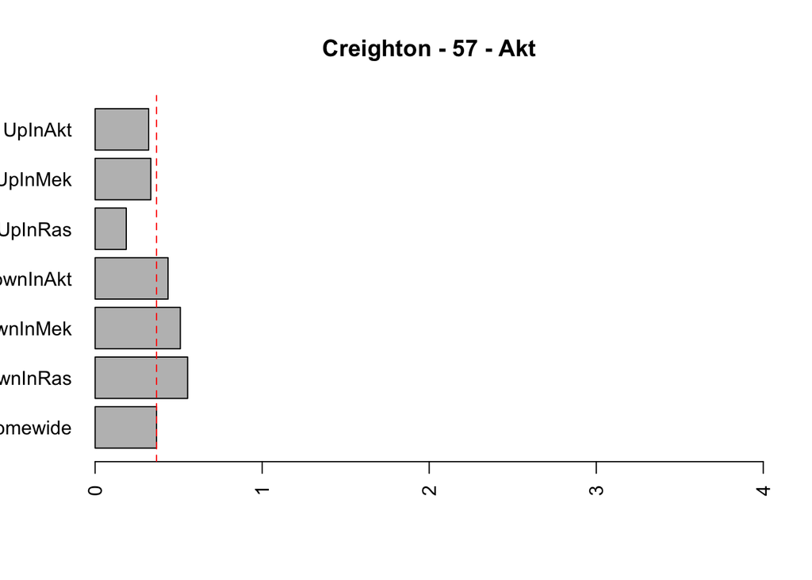

Plot the heatmap of genes in the Creighton gene set (AKT pathway):

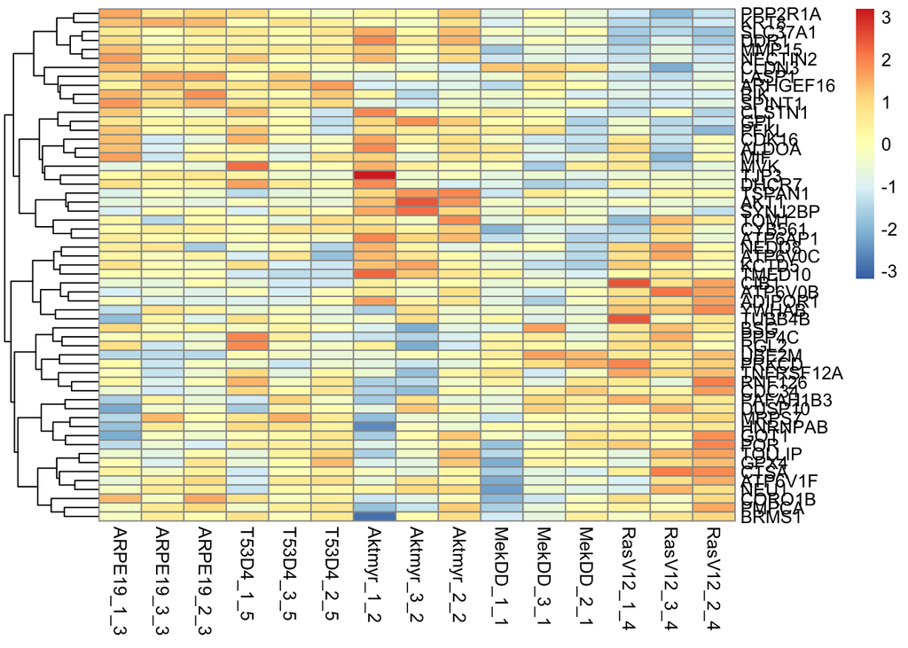

## Step 9: Loboda et al., 2010. RAS pathway - activated

```
##   UpInAkt   UpInMek   UpInRas
## 0.2459539 6.6505941 6.0074188
```

```
## DownInAkt DownInMek DownInRas
## 3.5743871 1.0440493 0.4722315
```

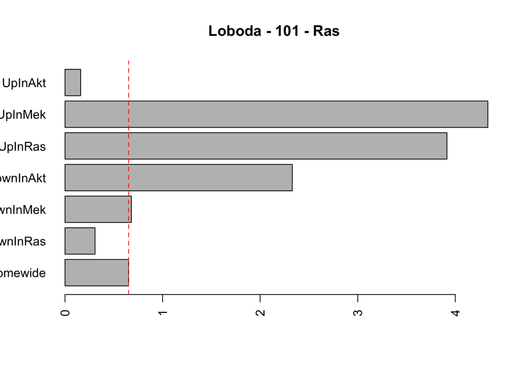

Plot the heatmap of genes in the Loboda Gene signature (RAS pathway):

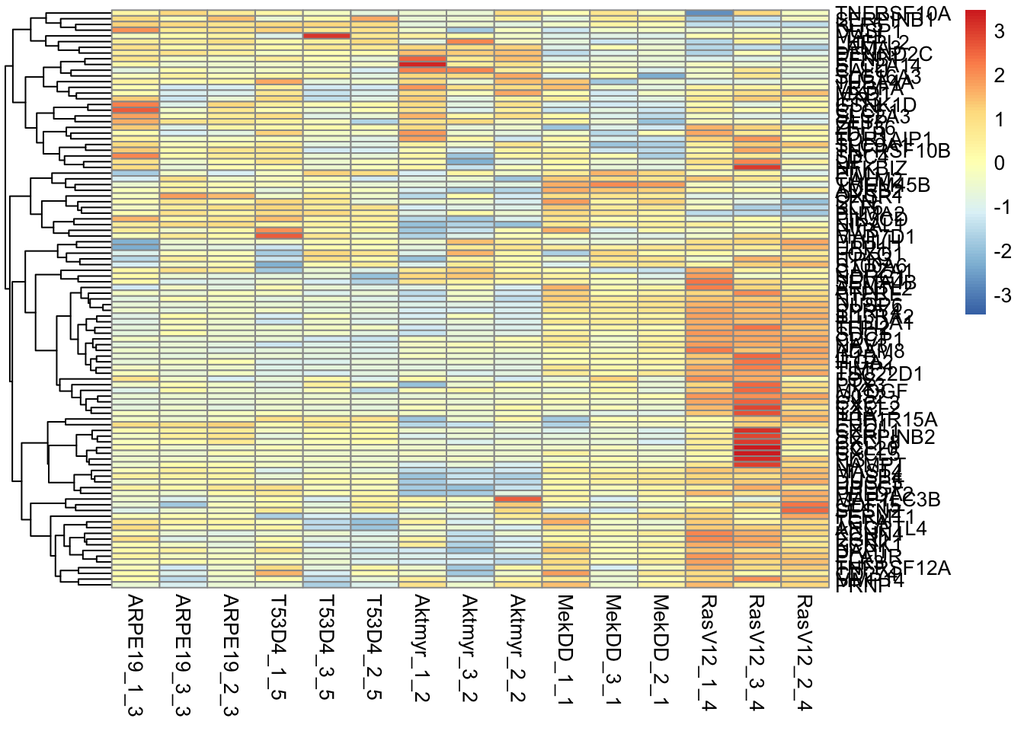

## Step 10: Gather up the P-values for enrichment and depletion rates

Here are the p-values reflecting the chance that there is enrichment in a gene signature within our geneset lits:

```
##                          UpInAkt      UpInMek      UpinRas    DowninAkt
## Dry_et_al_mek_18       0.5228865 7.629520e-07 1.201085e-05 2.125732e-08
## Pratilas_et_al_mek_50  0.8722563 4.219706e-07 2.989092e-14 1.261731e-13
## Wagle_et_al_mek_10     1.0000000 9.837576e-09 2.040869e-08 3.480504e-08
## Creighton_et_al_akt_57 0.6745758 6.724146e-01 9.125960e-01 4.661653e-01
## Loboda_ras_101         0.9844490 7.328553e-08 8.290773e-23 8.838786e-06
##                        DowninMek  DowninRas
## Dry_et_al_mek_18       1.0000000 0.03369732
## Pratilas_et_al_mek_50  1.0000000 0.99609878
## Wagle_et_al_mek_10     1.0000000 1.00000000
## Creighton_et_al_akt_57 0.3680125 0.13808785
## Loboda_ras_101         0.5366926 0.98472845
```

Here are the p-values reflecting the chance that there is depletion in a gene signature within our geneset lits:

```
##                           UpInAkt   UpInMek   UpinRas DowninAkt DowninMek
## Dry_et_al_mek_18       0.83774195 1.0000000 0.9999990 1.0000000 0.4983406
## Pratilas_et_al_mek_50  0.39653285 1.0000000 1.0000000 1.0000000 0.1441813
## Wagle_et_al_mek_10     0.66298479 1.0000000 1.0000000 1.0000000 0.6792088
## Creighton_et_al_akt_57 0.59576582 0.6974574 0.2352041 0.7545415 0.8302502
## Loboda_ras_101         0.08187633 1.0000000 1.0000000 0.9999980 0.6625693
##                        DowninRas
## Dry_et_al_mek_18       0.9919640
## Pratilas_et_al_mek_50  0.0268255
## Wagle_et_al_mek_10     0.3302920
## Creighton_et_al_akt_57 0.9294771
## Loboda_ras_101         0.0392682
```

## Step 11: Create dotplots for enrichment - fold change and p-values and create dotplots for depletion - fold chang and p-values

```
##                           UpInAkt    UpInMek     UpinRas
## Creighton_et_al_akt_57 0.39367128  0.3968802  0.09146203
## Pratilas_et_al_mek_50  0.13667203 14.6783301 31.14122163
## Dry_et_al_mek_18       0.64839086 14.0860707 11.32970006
## Wagle_et_al_mek_10     0.00000000 18.4370565 17.70730506
## Loboda_ras_101         0.01567323 16.4289026 50.84431391
```

```
##                      Var1      Var2 neglogpvalue RNAseq_num PubList folddeplete
## 1  Creighton_et_al_akt_57 DowninAkt 2.816451e-01          1       1   1.1875431
## 2   Pratilas_et_al_mek_50 DowninAkt 8.770762e-15          1       2   8.5740611
## 3        Dry_et_al_mek_18 DowninAkt 8.689662e-10          1       3  11.2816594
## 4      Wagle_et_al_mek_10 DowninAkt 5.949794e-10          1       4  15.7943231
## 5          Loboda_ras_101 DowninAkt 1.975603e-06          1       5   3.5743871
## 6  Creighton_et_al_akt_57 DowninMek 1.860282e-01          2       1   1.3874866
## 7   Pratilas_et_al_mek_50 DowninMek 1.936684e+00          2       2   0.0000000
## 8        Dry_et_al_mek_18 DowninMek 6.964715e-01          2       3   0.0000000
## 9      Wagle_et_al_mek_10 DowninMek 3.868267e-01          2       4   0.0000000
## 10         Loboda_ras_101 DowninMek 4.116301e-01          2       5   1.0440493
## 11 Creighton_et_al_akt_57 DowninRas 7.313315e-02          3       1   1.5061700
## 12  Pratilas_et_al_mek_50 DowninRas 3.618402e+00          3       2   0.1907815
## 13       Dry_et_al_mek_18 DowninRas 8.068501e-03          3       3   2.6497436
## 14     Wagle_et_al_mek_10 DowninRas 1.107778e+00          3       4   0.0000000
## 15         Loboda_ras_101 DowninRas 3.237340e+00          3       5   0.4722315
```

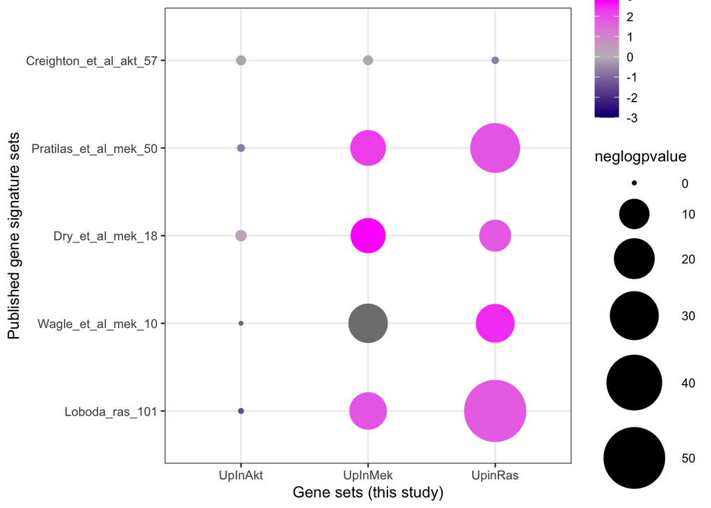

[figure not shown]

```r
citation()
```

```
##
##
##   R Core Team (2020). R: A language and environment for statistical
##   computing. R Foundation for Statistical Computing, Vienna, Austria.
##   URL https://www.R-project.org/.
##
## A BibTeX entry for LaTeX users is
##
##   @Manual{,
##     title = {R: A Language and Environment for Statistical Computing},
##     author = {{R Core Team}},
##     organization = {R Foundation for Statistical Computing},
##     address = {Vienna, Austria},
##     year = {2020},
##     url = {https://www.R-project.org/},
##   }
##
## We have invested a lot of time and effort in creating R, please cite it
## when using it for data analysis. See also 'citation("pkgname")' for
## citing R packages.
```